# Introduction to Computer Vision: Plant Seedlings Classification

## Problem Statement

### Context

In recent times, the field of agriculture has been in urgent need of modernizing, since the amount of manual work people need to put in to check if plants are growing correctly is still highly extensive. Despite several advances in agricultural technology, people working in the agricultural industry still need to have the ability to sort and recognize different plants and weeds, which takes a lot of time and effort in the long term. The potential is ripe for this trillion-dollar industry to be greatly impacted by technological innovations that cut down on the requirement for manual labor, and this is where Artificial Intelligence can actually benefit the workers in this field, as **the time and energy required to identify plant seedlings will be greatly shortened by the use of AI and Deep Learning.** The ability to do so far more efficiently and even more effectively than experienced manual labor, could lead to better crop yields, the freeing up of human inolvement for higher-order agricultural decision making, and in the long term will result in more sustainable environmental practices in agriculture as well.

### Objective

The aim of this project is to Build a Convolutional Neural Netowrk to classify plant seedlings into their respective categories.

### Data Dictionary

The Aarhus University Signal Processing group, in collaboration with the University of Southern Denmark, has recently released a dataset containing **images of unique plants belonging to 12 different species.**

- The dataset can be download from Olympus.
- The data file names are:
  - images.npy
  - Label.csv
- Due to the large volume of data, the images were converted to the images.npy file and the labels are also put into Labels.csv, so that you can work on the data/project seamlessly without having to worry about the high data volume.
- The goal of the project is to create a classifier capable of determining a plant's species from an image.

**List of Species**

- Black-grass
- Charlock
- Cleavers
- Common Chickweed
- Common Wheat
- Fat Hen
- Loose Silky-bent
- Maize
- Scentless Mayweed
- Shepherds Purse
- Small-flowered Cranesbill
- Sugar beet

#### **Note: Please use GPU runtime to execute the code efficiently**

## Importing necessary libraries

```python
import os
import numpy as np                                                                               # Importing numpy for Matrix Operations
import pandas as pd                                                                              # Importing pandas to read CSV files
import matplotlib.pyplot as plt                                                                  # Importting matplotlib for Plotting and visualizing images
import math                                                                                      # Importing math module to perform mathematical operations
import cv2                                                                                       # Importing openCV for image processing
import seaborn as sns                                                                            # Importing seaborn to plot graphs


# Tensorflow modules
import tensorflow as tf
from tensorflow.keras.preprocessing.image import ImageDataGenerator                              # Importing the ImageDataGenerator for data augmentation
from tensorflow.keras.models import Sequential                                                   # Importing the sequential module to define a sequential model
from tensorflow.keras.layers import Dense,Dropout,Flatten,Conv2D,MaxPooling2D,BatchNormalization # Defining all the layers to build our CNN Model
from tensorflow.keras.optimizers import Adam,SGD                                                 # Importing the optimizers which can be used in our model
from sklearn import preprocessing                                                                # Importing the preprocessing module to preprocess the data
from sklearn.model_selection import train_test_split                                             # Importing train_test_split function to split the data into train and test
from sklearn.metrics import confusion_matrix                                                     # Importing confusion_matrix to plot the confusion matrix
from sklearn.preprocessing import LabelBinarizer
# Display images using OpenCV
from google.colab.patches import cv2_imshow                                                      # Importing cv2_imshow from google.patches to display images
from sklearn.model_selection import train_test_split
from tensorflow.keras import backend
from keras.callbacks import ReduceLROnPlateau
import random
# Ignore warnings
import warnings
warnings.filterwarnings('ignore')
```

## Loading the dataset

```python
# Mount Google drive to access the dataset
# Run the below code if you using google colab
from google.colab import drive
drive.mount('/content/drive')
```

```python
# Load the image file of dataset
images = np.load('/content/drive/MyDrive/project6_ GL/images.npy')
```

```python
# Load the labels file of dataset
labels = pd.read_csv('/content/drive/MyDrive/project6_ GL/Labels.csv')
```

## Data Overview

### Understand the shape of the dataset

```python
print(images.shape)         # checking the shape of the data input
print(labels.shape)
```

```
(4750, 128, 128, 3)
(4750, 1)
```

```python
labels.head(10)
```

|  | Label |
| --- | --- |
| 0 | Small-flowered Cranesbill |
| 1 | Small-flowered Cranesbill |
| 2 | Small-flowered Cranesbill |
| 3 | Small-flowered Cranesbill |
| 4 | Small-flowered Cranesbill |
| 5 | Small-flowered Cranesbill |
| 6 | Small-flowered Cranesbill |
| 7 | Small-flowered Cranesbill |
| 8 | Small-flowered Cranesbill |
| 9 | Small-flowered Cranesbill |

## Exploratory Data Analysis

- EDA is an important part of any project involving data.
- It is important to investigate and understand the data better before building a model with it.
- A few questions have been mentioned below which will help you understand the data better.
- A thorough analysis of the data, in addition to the questions mentioned below, should be done.
1. How are these different category plant images different from each other?
2. Is the dataset provided an imbalance? (Check with using bar plots)

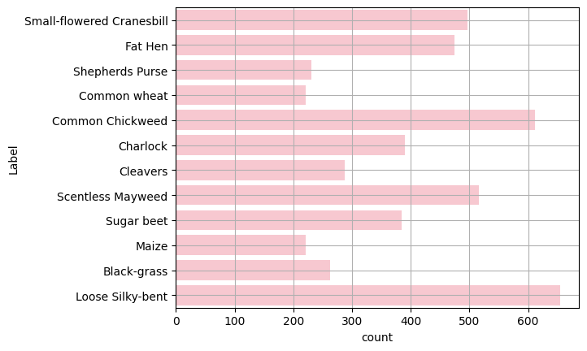

```python
 sns.countplot(labels['Label'],color='pink')
 plt.grid(True)
```

Data is unbalanced , certain samples example miaze ,common wheat,Shephards pulses are lower in number We may think to over sample it if the model will not perform well for these

## Data Pre-Processing

```python
##functions
```

```python
def plot_images(images,labels):
  num_classes=10                                                                  # Number of Classes
  categories=np.unique(labels)
  keys=dict(labels['Label'])                                                      # Obtaing the unique classes from y_train
  rows = 3                                                                        # Defining number of rows=3
  cols = 4                                                                        # Defining number of columns=4
  fig = plt.figure(figsize=(10, 8))                                               # Defining the figure size to 10x8
  for i in range(cols):
      for j in range(rows):
          random_index = np.random.randint(0, len(labels))                        # Generating random indices from the data and plotting the images
          ax = fig.add_subplot(rows, cols, i * rows + j + 1)                      # Adding subplots with 3 rows and 4 columns
          ax.imshow(images[random_index, :])                                      # Plotting the image
          ax.set_title(keys[random_index])
  plt.show()
```

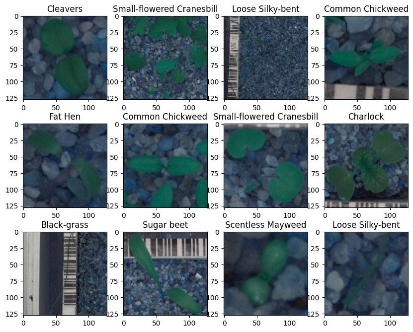

```python
plot_images(images,labels)
```

```python
cv2_imshow(images[5])
```

[output not shown]

```python
plt.imshow(images[5])
```

[output not shown]

```python
# From figure it does not seems like BGR images are bgr not RGB
# We can also observe that the images are being shown in different colors when plotted with openCV and matplotlib as OpenCV reads images in BGR format and this shows that the given numpy arrays were generated from the original images using OpenCV.
```

[output not shown]

### Convert the BGR images to RGB images.

```python
# Converting the images from BGR to RGB using cvtColor function of OpenCV
for i in range(len(images)):
  images[i] = cv2.cvtColor(images[i], cv2.COLOR_BGR2RGB)
```

[figure not shown]

```python
plot_images(images,labels)
```

### Resize the images

As the size of the images is large, it may be computationally expensive to train on these larger images; therefore, it is preferable to reduce the image size from 128 to 64.

```python
images_decreased=[]
height = 64
width = 64
dimensions = (width, height)
for i in range(len(images)):
  images_decreased.append( cv2.resize(images[i], dimensions, interpolation=cv2.INTER_LINEAR))
```

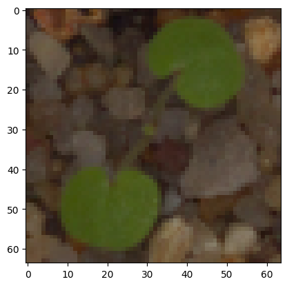

```python
plt.imshow(images_decreased[5])
```

```python
# Applying Gaussian Blur to denoise the images
images_gb=[]
for i in range(len(images)):
  # gb[i] = cv2.cvtColor(images[i], cv2.COLOR_BGR2RGB)
  images_gb.append(cv2.GaussianBlur(images[i], ksize =(3,3),sigmaX =  0))
```

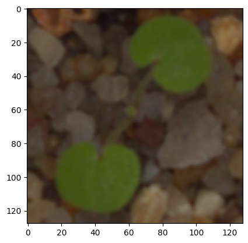

```python
plt.imshow(images_gb[5])
```

### Data Preparation for Modeling

- Before you proceed to build a model, you need to split the data into train, test, and validation to be able to evaluate the model that you build on the train data
- You'll have to encode categorical features and scale the pixel values.
- You will build a model using the train data and then check its performance

**Split the dataset**

```python
from sklearn.model_selection import train_test_split
X_temp, X_test, y_temp, y_test = train_test_split(np.array(images_decreased),labels , test_size=0.1, random_state=42,stratify=labels)
X_train, X_val, y_train, y_val = train_test_split(X_temp,y_temp , test_size=0.1, random_state=42,stratify=y_temp)
```

```python
print(X_train.shape,y_train.shape)
print(X_val.shape,y_val.shape)
print(X_test.shape,y_test.shape)
```

```
(3847, 64, 64, 3) (3847, 1)
(428, 64, 64, 3) (428, 1)
(475, 64, 64, 3) (475, 1)
```

### Encode the target labels

```python
# Convert labels from names to one hot vectors.

from sklearn.preprocessing import LabelBinarizer
enc = LabelBinarizer()
y_train_encoded = enc.fit_transform(y_train)
y_val_encoded=enc.transform(y_val)
y_test_encoded=enc.transform(y_test)
```

### Data Normalization

```python
# Normalizing the image pixels
X_train_normalized = X_train.astype('float32')/255.0
X_val_normalized = X_val.astype('float32')/255.0
X_test_normalized = X_test.astype('float32')/255.0
```

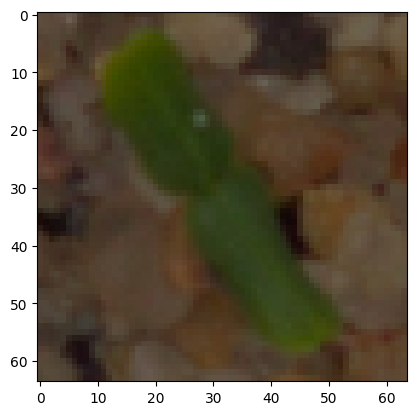

```python
plt.imshow(X_train_normalized[5])
```

## Model Building

```python
# Clearing backend
from tensorflow.keras import backend
backend.clear_session()
```

```python
# Fixing the seed for random number generators
import random
np.random.seed(40)
random.seed(40)
tf.random.set_seed(40)
```

```python
# Intializing a sequential model
model = Sequential()

# Adding first conv layer with 64 filters and kernel size 3x3 , padding 'same' provides the output size same as the input size
# Input_shape denotes input image dimension of images
model.add(Conv2D(64, (3, 3), activation='relu', padding="same", input_shape=(64, 64, 3)))

# Adding max pooling to reduce the size of output of first conv layer
model.add(MaxPooling2D((2, 2), padding = 'same'))

model.add(Conv2D(32, (3, 3), activation='relu', padding="same"))
model.add(MaxPooling2D((2, 2), padding = 'same'))

# flattening the output of the conv layer after max pooling to make it ready for creating dense connections
model.add(Flatten())

# Adding a fully connected dense layer with 100 neurons
model.add(Dense(16, activation='relu'))
model.add(Dropout(0.3))
# Adding the output layer with 12 neurons and activation functions as softmax since this is a multi-class classification problem
model.add(Dense(12, activation='softmax'))

# Using SGD Optimizer
# opt = SGD(learning_rate=0.01, momentum=0.9)
opt=Adam()
# Compile model
model.compile(optimizer=opt, loss='categorical_crossentropy', metrics=['accuracy'])

# Generating the summary of the model
model.summary()
```

```
Model: "sequential"
_________________________________________________________________
 Layer (type)                Output Shape              Param #
=================================================================
 conv2d (Conv2D)             (None, 64, 64, 64)        1792

 max_pooling2d (MaxPooling2  (None, 32, 32, 64)        0
 D)

 conv2d_1 (Conv2D)           (None, 32, 32, 32)        18464

 max_pooling2d_1 (MaxPoolin  (None, 16, 16, 32)        0
 g2D)

 flatten (Flatten)           (None, 8192)              0

 dense (Dense)               (None, 16)                131088

 dropout (Dropout)           (None, 16)                0

 dense_1 (Dense)             (None, 12)                204

=================================================================
Total params: 151548 (591.98 KB)
Trainable params: 151548 (591.98 KB)
Non-trainable params: 0 (0.00 Byte)
_________________________________________________________________
```

# Fitting the model to train data

```python
print(f"Shape of y_train_encoded: {y_train_encoded.shape}")
print(f"Shape of y_val_encoded: {y_val_encoded.shape}")
print(f"Shape of X_train_: {X_train_normalized.shape}")
print(f"Shape of X_val: {X_val_normalized.shape}")
```

```
Shape of y_train_encoded: (3847, 12)
Shape of y_val_encoded: (428, 12)
Shape of X_train_: (3847, 64, 64, 3)
Shape of X_val: (428, 64, 64, 3)
```

```python
history_1 = model.fit(
            X_train_normalized, y_train_encoded,
            epochs=30,
            validation_data=(X_val_normalized,y_val_encoded),
            batch_size=32,
            verbose=2
)
```

```
121/121 - 7s - loss: 2.4676 - accuracy: 0.1196 - val_loss: 2.4443 - val_accuracy: 0.1379 - 7s/epoch - 56ms/step
121/121 - 1s - loss: 2.4428 - accuracy: 0.1414 - val_loss: 2.4181 - val_accuracy: 0.1379 - 874ms/epoch - 7ms/step
121/121 - 1s - loss: 2.2806 - accuracy: 0.2272 - val_loss: 2.1017 - val_accuracy: 0.3318 - 904ms/epoch - 7ms/step
121/121 - 1s - loss: 2.0430 - accuracy: 0.2943 - val_loss: 1.8843 - val_accuracy: 0.3505 - 945ms/epoch - 8ms/step
121/121 - 1s - loss: 1.9461 - accuracy: 0.3138 - val_loss: 1.7358 - val_accuracy: 0.3505 - 760ms/epoch - 6ms/step
121/121 - 1s - loss: 1.8670 - accuracy: 0.3267 - val_loss: 1.7279 - val_accuracy: 0.3902 - 704ms/epoch - 6ms/step
121/121 - 1s - loss: 1.8085 - accuracy: 0.3343 - val_loss: 1.5981 - val_accuracy: 0.4042 - 727ms/epoch - 6ms/step
121/121 - 1s - loss: 1.7606 - accuracy: 0.3460 - val_loss: 1.5569 - val_accuracy: 0.4626 - 721ms/epoch - 6ms/step
121/121 - 1s - loss: 1.6898 - accuracy: 0.3725 - val_loss: 1.4837 - val_accuracy: 0.4650 - 715ms/epoch - 6ms/step
121/121 - 1s - loss: 1.6569 - accuracy: 0.3829 - val_loss: 1.4680 - val_accuracy: 0.5000 - 713ms/epoch - 6ms/step
121/121 - 1s - loss: 1.6043 - accuracy: 0.4073 - val_loss: 1.4021 - val_accuracy: 0.5257 - 717ms/epoch - 6ms/step
121/121 - 1s - loss: 1.6004 - accuracy: 0.4104 - val_loss: 1.3771 - val_accuracy: 0.4907 - 713ms/epoch - 6ms/step
121/121 - 1s - loss: 1.5639 - accuracy: 0.4141 - val_loss: 1.3372 - val_accuracy: 0.5467 - 688ms/epoch - 6ms/step
121/121 - 1s - loss: 1.5578 - accuracy: 0.4112 - val_loss: 1.3506 - val_accuracy: 0.5374 - 711ms/epoch - 6ms/step
121/121 - 1s - loss: 1.5577 - accuracy: 0.4151 - val_loss: 1.3388 - val_accuracy: 0.5397 - 709ms/epoch - 6ms/step
121/121 - 1s - loss: 1.5159 - accuracy: 0.4307 - val_loss: 1.3383 - val_accuracy: 0.5397 - 694ms/epoch - 6ms/step
121/121 - 1s - loss: 1.4864 - accuracy: 0.4442 - val_loss: 1.4241 - val_accuracy: 0.5140 - 680ms/epoch - 6ms/step
121/121 - 1s - loss: 1.4977 - accuracy: 0.4385 - val_loss: 1.2530 - val_accuracy: 0.5631 - 707ms/epoch - 6ms/step
121/121 - 1s - loss: 1.4707 - accuracy: 0.4481 - val_loss: 1.2643 - val_accuracy: 0.5771 - 809ms/epoch - 7ms/step
121/121 - 1s - loss: 1.4755 - accuracy: 0.4458 - val_loss: 1.2852 - val_accuracy: 0.5584 - 828ms/epoch - 7ms/step
121/121 - 1s - loss: 1.4639 - accuracy: 0.4463 - val_loss: 1.2813 - val_accuracy: 0.5607 - 938ms/epoch - 8ms/step
121/121 - 1s - loss: 1.4456 - accuracy: 0.4596 - val_loss: 1.2369 - val_accuracy: 0.5864 - 754ms/epoch - 6ms/step
121/121 - 1s - loss: 1.3970 - accuracy: 0.4687 - val_loss: 1.2344 - val_accuracy: 0.5818 - 692ms/epoch - 6ms/step
121/121 - 1s - loss: 1.4253 - accuracy: 0.4622 - val_loss: 1.2444 - val_accuracy: 0.5771 - 683ms/epoch - 6ms/step
121/121 - 1s - loss: 1.3908 - accuracy: 0.4736 - val_loss: 1.2553 - val_accuracy: 0.5748 - 686ms/epoch - 6ms/step
121/121 - 1s - loss: 1.3911 - accuracy: 0.4726 - val_loss: 1.2370 - val_accuracy: 0.6005 - 701ms/epoch - 6ms/step
121/121 - 1s - loss: 1.3911 - accuracy: 0.4775 - val_loss: 1.2468 - val_accuracy: 0.5864 - 724ms/epoch - 6ms/step
121/121 - 1s - loss: 1.3801 - accuracy: 0.4905 - val_loss: 1.2461 - val_accuracy: 0.5748 - 716ms/epoch - 6ms/step
121/121 - 1s - loss: 1.3777 - accuracy: 0.4804 - val_loss: 1.2815 - val_accuracy: 0.5771 - 693ms/epoch - 6ms/step
121/121 - 1s - loss: 1.3323 - accuracy: 0.4942 - val_loss: 1.2589 - val_accuracy: 0.5981 - 712ms/epoch - 6ms/step
```

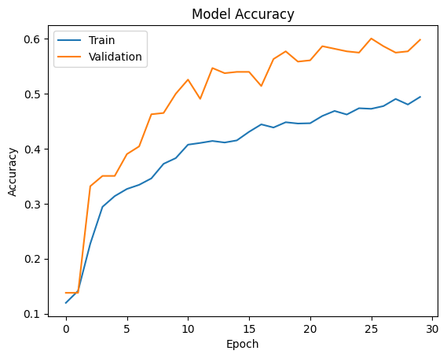

```python
plt.plot(history_1.history['accuracy'])
plt.plot(history_1.history['val_accuracy'])
plt.title('Model Accuracy')
plt.ylabel('Accuracy')
plt.xlabel('Epoch')
plt.legend(['Train', 'Validation'], loc='upper left')
plt.show()
```

```python
#Model1 test on test data
accuracy = model.evaluate(X_test_normalized, y_test_encoded, verbose=2)
```

```
15/15 - 0s - loss: 1.2736 - accuracy: 0.6042 - 161ms/epoch - 11ms/step
```

```python
# Here we would get the output as probablities for each category
y_pred=model.predict(X_test_normalized)
```

```python
y_pred
```

```
array([[7.01893335e-11, 3.90217785e-04, 9.26912058e-09, ...,
        6.85743764e-02, 2.79635060e-06, 4.33287444e-03],
       [1.83658769e-10, 1.39142550e-03, 3.65146057e-04, ...,
        3.16218147e-03, 9.75984335e-01, 1.39756845e-02],
       [2.24178498e-09, 1.24437080e-04, 6.29725764e-05, ...,
        1.34962506e-03, 9.59586442e-01, 1.94384176e-02],
       ...,
       [2.36470833e-01, 7.18769558e-11, 4.06430336e-05, ...,
        4.59662780e-10, 1.07622311e-08, 3.06953625e-05],
       [1.15793769e-03, 3.67175266e-02, 3.88146611e-03, ...,
        8.41711015e-02, 4.82489500e-04, 1.35173574e-01],
       [1.16914016e-05, 2.61749234e-02, 1.14236597e-03, ...,
        1.88927174e-01, 9.78867784e-02, 1.98178679e-01]], dtype=float32)
```

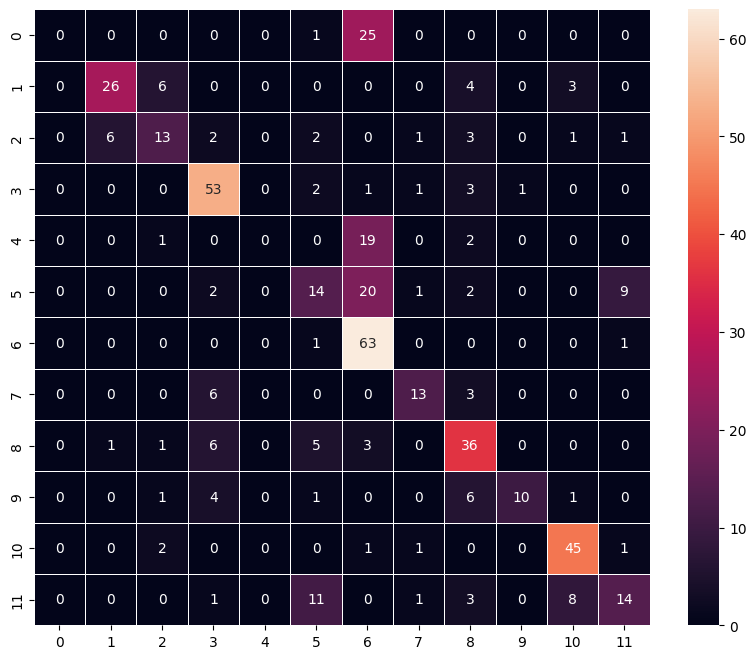

```python
# Obtaining the categorical values from y_test_encoded and y_pred
y_pred_arg=np.argmax(y_pred,axis=1)
y_test_arg=np.argmax(y_test_encoded,axis=1)

# Plotting the Confusion Matrix using confusion matrix() function which is also predefined tensorflow module
confusion_matrix = tf.math.confusion_matrix(y_test_arg,y_pred_arg)
f, ax = plt.subplots(figsize=(10, 8))
sns.heatmap(
    confusion_matrix,
    annot=True,
    linewidths=.4,
    fmt="d",
    square=True,
    ax=ax
)
plt.show()
```

# model 1 summary

Training data is not fitting well enough 1 we can increase the nurons 2 increase the layers

# Model 2

```python
# Clearing backend
from tensorflow.keras import backend
backend.clear_session()
# Fixing the seed for random number generators
import random
np.random.seed(40)
random.seed(40)
tf.random.set_seed(40)
```

```python
# Intializing a sequential model
model2 = Sequential()

# Adding first conv layer with 64 filters and kernel size 3x3 , padding 'same' provides the output size same as the input size
# Input_shape denotes input image dimension of images
model2.add(Conv2D(64, (3, 3), activation='relu', padding="same", input_shape=(64, 64, 3)))

# Adding max pooling to reduce the size of output of first conv layer
model2.add(MaxPooling2D((2, 2), padding = 'same'))

model2.add(Conv2D(32, (3, 3), activation='relu', padding="same"))
model2.add(MaxPooling2D((2, 2), padding = 'same'))

# flattening the output of the conv layer after max pooling to make it ready for creating dense connections
model2.add(Flatten())

# Adding a fully connected dense layer with 200 neurons
model2.add(Dense(200, activation='relu'))
model2.add(Dropout(0.3))

# Adding the output layer with 12 neurons and activation functions as softmax since this is a multi-class classification problem
model2.add(Dense(12, activation='softmax'))

# Using SGD Optimizer
# opt = SGD(learning_rate=0.01, momentum=0.9)
opt=Adam()
# Compile model
model2.compile(optimizer=opt, loss='categorical_crossentropy', metrics=['accuracy'])

# Generating the summary of the model
model2.summary()
```

```
Model: "sequential"
_________________________________________________________________
 Layer (type)                Output Shape              Param #
=================================================================
 conv2d (Conv2D)             (None, 64, 64, 64)        1792

 max_pooling2d (MaxPooling2  (None, 32, 32, 64)        0
 D)

 conv2d_1 (Conv2D)           (None, 32, 32, 32)        18464

 max_pooling2d_1 (MaxPoolin  (None, 16, 16, 32)        0
 g2D)

 flatten (Flatten)           (None, 8192)              0

 dense (Dense)               (None, 200)               1638600

 dropout (Dropout)           (None, 200)               0

 dense_1 (Dense)             (None, 12)                2412

=================================================================
Total params: 1661268 (6.34 MB)
Trainable params: 1661268 (6.34 MB)
Non-trainable params: 0 (0.00 Byte)
_________________________________________________________________
```

```python
history_2 = model2.fit(
            X_train_normalized, y_train_encoded,
            epochs=30,
            validation_data=(X_val_normalized,y_val_encoded),
            batch_size=32,
            verbose=2
)
```

```
121/121 - 3s - loss: 2.1175 - accuracy: 0.2641 - val_loss: 1.5599 - val_accuracy: 0.4603 - 3s/epoch - 24ms/step
121/121 - 1s - loss: 1.4544 - accuracy: 0.4949 - val_loss: 1.2319 - val_accuracy: 0.5818 - 882ms/epoch - 7ms/step
121/121 - 1s - loss: 1.1707 - accuracy: 0.5999 - val_loss: 1.0629 - val_accuracy: 0.6612 - 756ms/epoch - 6ms/step
121/121 - 1s - loss: 1.0195 - accuracy: 0.6525 - val_loss: 0.9328 - val_accuracy: 0.6986 - 727ms/epoch - 6ms/step
121/121 - 1s - loss: 0.8813 - accuracy: 0.6917 - val_loss: 0.9064 - val_accuracy: 0.6916 - 749ms/epoch - 6ms/step
121/121 - 1s - loss: 0.7623 - accuracy: 0.7312 - val_loss: 0.9045 - val_accuracy: 0.6752 - 727ms/epoch - 6ms/step
121/121 - 1s - loss: 0.7040 - accuracy: 0.7611 - val_loss: 0.8197 - val_accuracy: 0.7383 - 746ms/epoch - 6ms/step
121/121 - 1s - loss: 0.5725 - accuracy: 0.8071 - val_loss: 0.7881 - val_accuracy: 0.7570 - 731ms/epoch - 6ms/step
121/121 - 1s - loss: 0.5173 - accuracy: 0.8261 - val_loss: 0.7265 - val_accuracy: 0.7804 - 752ms/epoch - 6ms/step
121/121 - 1s - loss: 0.4601 - accuracy: 0.8495 - val_loss: 0.7913 - val_accuracy: 0.7664 - 743ms/epoch - 6ms/step
121/121 - 1s - loss: 0.3893 - accuracy: 0.8721 - val_loss: 0.8280 - val_accuracy: 0.7407 - 752ms/epoch - 6ms/step
121/121 - 1s - loss: 0.3801 - accuracy: 0.8716 - val_loss: 0.7899 - val_accuracy: 0.7921 - 723ms/epoch - 6ms/step
121/121 - 1s - loss: 0.3176 - accuracy: 0.8950 - val_loss: 0.8447 - val_accuracy: 0.7477 - 734ms/epoch - 6ms/step
121/121 - 1s - loss: 0.2877 - accuracy: 0.9033 - val_loss: 0.8590 - val_accuracy: 0.7593 - 723ms/epoch - 6ms/step
121/121 - 1s - loss: 0.2492 - accuracy: 0.9134 - val_loss: 0.8455 - val_accuracy: 0.7734 - 761ms/epoch - 6ms/step
121/121 - 1s - loss: 0.2022 - accuracy: 0.9332 - val_loss: 0.8753 - val_accuracy: 0.7757 - 819ms/epoch - 7ms/step
121/121 - 1s - loss: 0.1774 - accuracy: 0.9379 - val_loss: 0.8260 - val_accuracy: 0.7757 - 827ms/epoch - 7ms/step
121/121 - 1s - loss: 0.1707 - accuracy: 0.9467 - val_loss: 0.9356 - val_accuracy: 0.7266 - 861ms/epoch - 7ms/step
121/121 - 1s - loss: 0.1496 - accuracy: 0.9532 - val_loss: 0.9810 - val_accuracy: 0.7477 - 840ms/epoch - 7ms/step
121/121 - 1s - loss: 0.1350 - accuracy: 0.9592 - val_loss: 0.9746 - val_accuracy: 0.7570 - 749ms/epoch - 6ms/step
121/121 - 1s - loss: 0.1239 - accuracy: 0.9581 - val_loss: 0.9977 - val_accuracy: 0.7804 - 737ms/epoch - 6ms/step
121/121 - 1s - loss: 0.1118 - accuracy: 0.9644 - val_loss: 1.1889 - val_accuracy: 0.7453 - 733ms/epoch - 6ms/step
121/121 - 1s - loss: 0.1027 - accuracy: 0.9659 - val_loss: 0.9913 - val_accuracy: 0.7640 - 758ms/epoch - 6ms/step
121/121 - 1s - loss: 0.0827 - accuracy: 0.9709 - val_loss: 0.9745 - val_accuracy: 0.7757 - 755ms/epoch - 6ms/step
121/121 - 1s - loss: 0.0973 - accuracy: 0.9693 - val_loss: 1.0205 - val_accuracy: 0.7850 - 733ms/epoch - 6ms/step
121/121 - 1s - loss: 0.0779 - accuracy: 0.9732 - val_loss: 1.0704 - val_accuracy: 0.7617 - 915ms/epoch - 8ms/step
121/121 - 1s - loss: 0.0823 - accuracy: 0.9714 - val_loss: 1.1067 - val_accuracy: 0.7523 - 1s/epoch - 9ms/step
121/121 - 1s - loss: 0.0838 - accuracy: 0.9735 - val_loss: 1.0314 - val_accuracy: 0.7921 - 1s/epoch - 10ms/step
121/121 - 1s - loss: 0.0757 - accuracy: 0.9769 - val_loss: 1.0130 - val_accuracy: 0.7827 - 1s/epoch - 10ms/step
121/121 - 1s - loss: 0.0774 - accuracy: 0.9766 - val_loss: 1.0973 - val_accuracy: 0.7523 - 730ms/epoch - 6ms/step
```

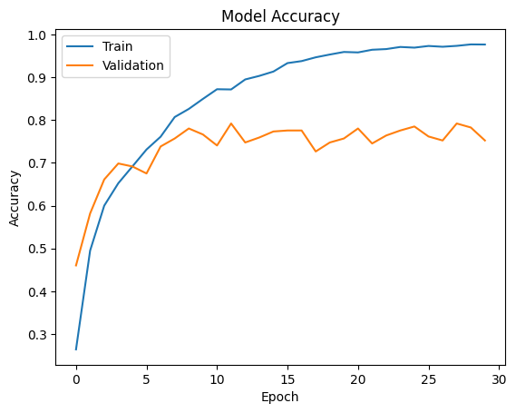

```python
plt.plot(history_2.history['accuracy'])
plt.plot(history_2.history['val_accuracy'])
plt.title('Model Accuracy')
plt.ylabel('Accuracy')
plt.xlabel('Epoch')
plt.legend(['Train', 'Validation'], loc='upper left')
plt.show()
```

```python
accuracy = model2.evaluate(X_test_normalized, y_test_encoded, verbose=2)
```

```
15/15 - 0s - loss: 1.2487 - accuracy: 0.7411 - 71ms/epoch - 5ms/step
```

```python
# Here we would get the output as probablities for each category
y_pred=model2.predict(X_test_normalized)
```

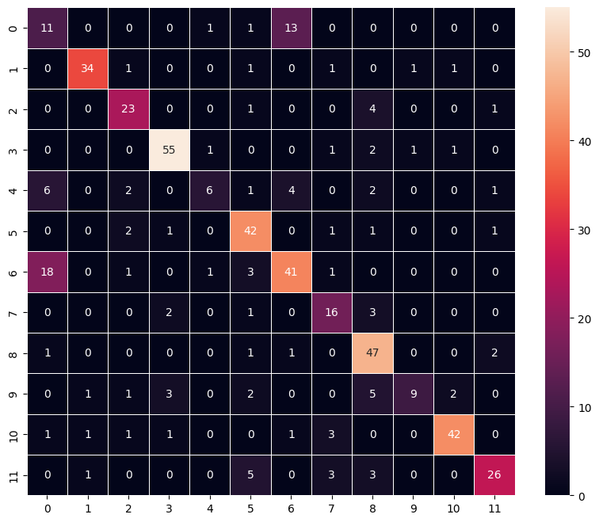

```python
# Obtaining the categorical values from y_test_encoded and y_pred
y_pred_arg=np.argmax(y_pred,axis=1)
y_test_arg=np.argmax(y_test_encoded,axis=1)

# Plotting the Confusion Matrix using confusion matrix() function which is also predefined tensorflow module
confusion_matrix = tf.math.confusion_matrix(y_test_arg,y_pred_arg)
f, ax = plt.subplots(figsize=(10, 8))
sns.heatmap(
    confusion_matrix,
    annot=True,
    linewidths=.4,
    fmt="d",
    square=True,
    ax=ax
)
plt.show()
```

## Model Performance Improvement

**Reducing the Learning Rate:**

**Hint**: Use **ReduceLRonPlateau()** function that will be used to decrease the learning rate by some factor, if the loss is not decreasing for some time. This may start decreasing the loss at a smaller learning rate. There is a possibility that the loss may still not decrease. This may lead to executing the learning rate reduction again in an attempt to achieve a lower loss.

# Model 3 - With reduce learning and data augmentation

```python
# Clearing backend
from tensorflow.keras import backend
backend.clear_session()
# Fixing the seed for random number generators
import random
np.random.seed(40)
random.seed(40)
tf.random.set_seed(40)
```

```python
# Code to monitor val_accuracy
learning_rate_reduction = ReduceLROnPlateau(monitor='val_accuracy',
                                            patience=3,
                                            verbose=1,
                                            factor=0.5,
                                            min_lr=0.00001)
```

```python
train_datagen = ImageDataGenerator(
                              rotation_range=20,
                              fill_mode='nearest'
                              )
```

```python
# Intializing a sequential model
model3 = Sequential()

# Adding first conv layer with 64 filters and kernel size 3x3 , padding 'same' provides the output size same as the input size
# Input_shape denotes input image dimension of images
model3.add(Conv2D(64, (3, 3), activation='relu', padding="same", input_shape=(64, 64, 3)))

# Adding max pooling to reduce the size of output of first conv layer
model3.add(MaxPooling2D((2, 2), padding = 'same'))

model3.add(Conv2D(32, (3, 3), activation='relu', padding="same"))
model3.add(MaxPooling2D((2, 2), padding = 'same'))

# flattening the output of the conv layer after max pooling to make it ready for creating dense connections
model3.add(Flatten())

# Adding a fully connected dense layer with 200 neurons
model3.add(Dense(200, activation='relu'))
model3.add(Dropout(0.3))

# Adding the output layer with 12 neurons and activation functions as softmax since this is a multi-class classification problem
model3.add(Dense(12, activation='softmax'))

# Using SGD Optimizer
# opt = SGD(learning_rate=0.01, momentum=0.9)
opt=Adam()
# Compile model
model3.compile(optimizer=opt, loss='categorical_crossentropy', metrics=['accuracy'])

# Generating the summary of the model
model3.summary()
```

```
Model: "sequential"
_________________________________________________________________
 Layer (type)                Output Shape              Param #
=================================================================
 conv2d (Conv2D)             (None, 64, 64, 64)        1792

 max_pooling2d (MaxPooling2  (None, 32, 32, 64)        0
 D)

 conv2d_1 (Conv2D)           (None, 32, 32, 32)        18464

 max_pooling2d_1 (MaxPoolin  (None, 16, 16, 32)        0
 g2D)

 flatten (Flatten)           (None, 8192)              0

 dense (Dense)               (None, 200)               1638600

 dropout (Dropout)           (None, 200)               0

 dense_1 (Dense)             (None, 12)                2412

=================================================================
Total params: 1661268 (6.34 MB)
Trainable params: 1661268 (6.34 MB)
Non-trainable params: 0 (0.00 Byte)
_________________________________________________________________
```

```python
# Epochs
epochs = 30
# Batch size
batch_size = 32

history3 = model3.fit(train_datagen.flow(X_train_normalized,y_train_encoded,
                                       batch_size=batch_size,
                                       shuffle=False),
                                       epochs=epochs,
                                       steps_per_epoch=X_train_normalized.shape[0] // batch_size,
                                       validation_data=(X_val_normalized,y_val_encoded),
                                       verbose=1,callbacks=[learning_rate_reduction])
```

```
Epoch 7: ReduceLROnPlateau reducing learning rate to 0.0005000000237487257.
Epoch 17: ReduceLROnPlateau reducing learning rate to 0.0002500000118743628.
Epoch 21: ReduceLROnPlateau reducing learning rate to 0.0001250000059371814.
Epoch 24: ReduceLROnPlateau reducing learning rate to 6.25000029685907e-05.
Epoch 27: ReduceLROnPlateau reducing learning rate to 3.125000148429535e-05.
```

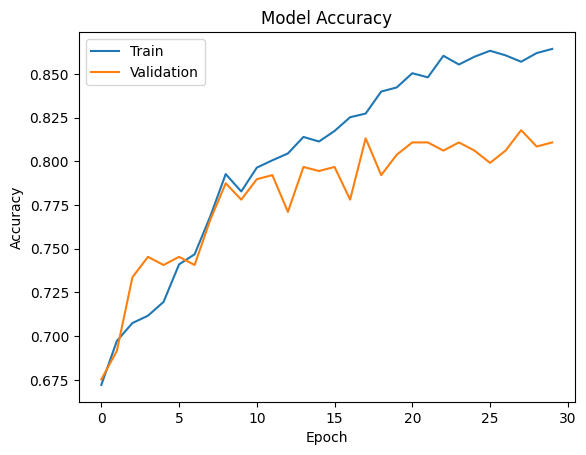

```python
plt.plot(history3.history['accuracy'])
plt.plot(history3.history['val_accuracy'])
plt.title('Model Accuracy')
plt.ylabel('Accuracy')
plt.xlabel('Epoch')
plt.legend(['Train', 'Validation'], loc='upper left')
plt.show()
```

```python
accuracy = model3.evaluate(X_test_normalized, y_test_encoded, verbose=2)
```

```
15/15 - 0s - loss: 0.7498 - accuracy: 0.8021 - 69ms/epoch - 5ms/step
```

```python
# Here we would get the output as probablities for each category
y_pred=model3.predict(X_test_normalized)
```

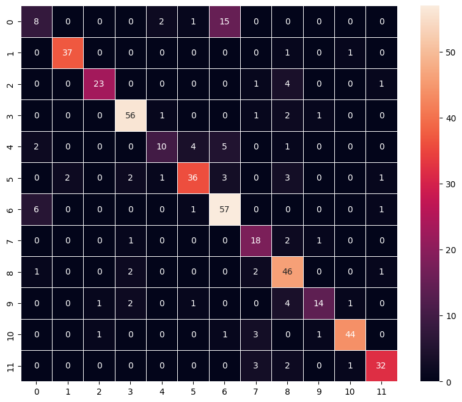

```python
# Obtaining the categorical values from y_test_encoded and y_pred
y_pred_arg=np.argmax(y_pred,axis=1)
y_test_arg=np.argmax(y_test_encoded,axis=1)

# Plotting the Confusion Matrix using confusion matrix() function which is also predefined tensorflow module
confusion_matrix = tf.math.confusion_matrix(y_test_arg,y_pred_arg)
f, ax = plt.subplots(figsize=(10, 8))
sns.heatmap(
    confusion_matrix,
    annot=True,
    linewidths=.4,
    fmt="d",
    square=True,
    ax=ax
)
plt.show()
```

## Final Model

- We should select **Model 3** as the accuracy on train data is staisfactory in 85% while test and validation to be 80%
- Model 1 was not able to predict even on averge it was like fliping a coin
- Adding more neuron in Model 2 certainly increase the prediction significantly however from the curve below we can clearly see the data to be overfiting

### Visualizing the prediction

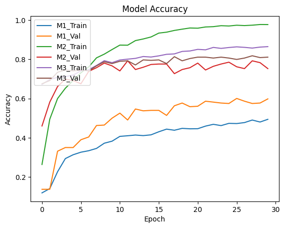

```python
plt.plot(history_1.history['accuracy'])
plt.plot(history_1.history['val_accuracy'])
plt.plot(history_2.history['accuracy'])
plt.plot(history_2.history['val_accuracy'])
plt.plot(history3.history['accuracy'])
plt.plot(history3.history['val_accuracy'])
plt.title('Model Accuracy')
plt.ylabel('Accuracy')
plt.xlabel('Epoch')
plt.legend(['M1_Train', 'M1_Val','M2_Train', 'M2_Val','M3_Train', 'M3_Val'], loc='upper left')
plt.show()
```

```python
pd.DataFrame({'Models':['Base CNN Model','CNN Model with more neurons','Model with Data AUG and reduce learn'],'Train Accuracy':['49%','97%','85%'],'Validation Accuracy':['59%','78%','80%'],'Test Accuracy':['60%','74%','80%']})
```

|  | Models | Train Accuracy | Validation Accuracy | Test Accuracy |
| --- | --- | --- | --- | --- |
| 0 | Base CNN Model | 49% | 59% | 60% |
| 1 | CNN Model with more neurons | 97% | 78% | 74% |
| 2 | Model with Data AUG and reduce learn | 85% | 80% | 80% |